# Longitudinal Age Modeling & Variance Partitioning Benchmark

Comprehensive Evaluation of Spline Complexity and Empirical Variance

Author

Gemini CLI

Published

May 2, 2026

## Executive Summary

This report synthesizes the results of extensive benchmarking to optimize the modeling of age trajectories (ages 0–14) in longitudinal immune profiles. We evaluate spline families, complexity, and variance partitioning methodologies to robustly separate individual identity (*Subject*) from developmental trends (*Age*).

## Analysis 1: Spline Architecture & Complexity (AIC Tournament)

We compared Natural Cubic Splines (`ns`) and Piecewise Linear Splines (`lspline`) across 10 levels of complexity (df/knots).

### Statistical Fit & Parsimony

The “AIC Tournament” evaluates which complexity best fits the data while penalizing for over-parameterization.

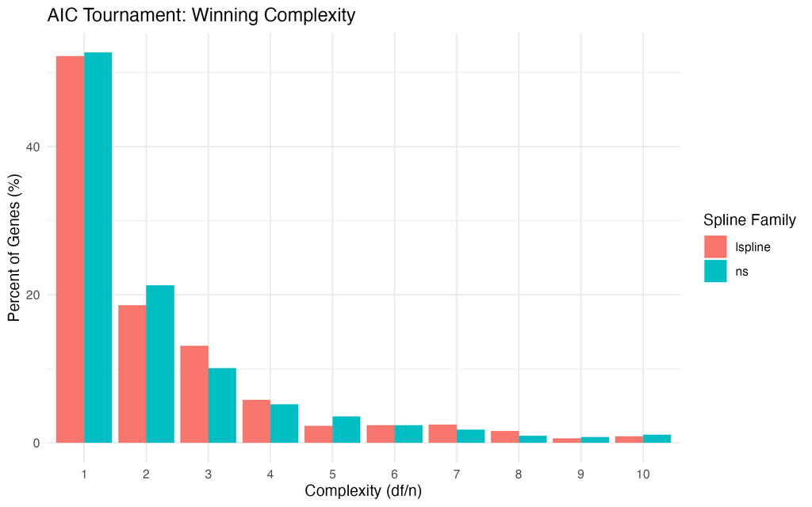

**AIC Tournament:** For most genes, lower complexity (df=1-2) is statistically optimal.

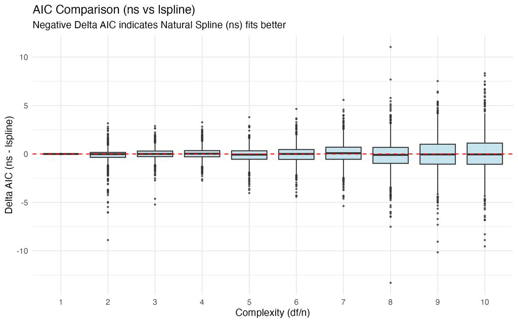

### Robustness of Subject Identity

A critical concern was whether increasing age complexity would “steal” variance from the Subject component.

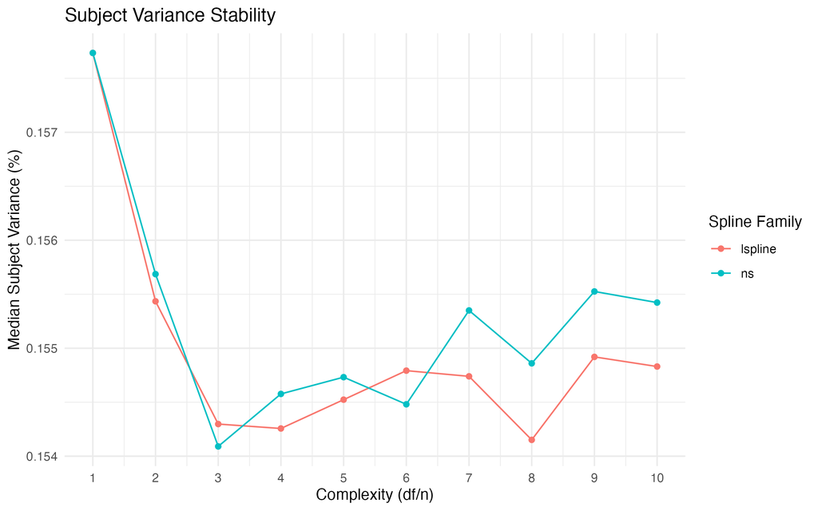

**Subject Variance Stability:** Median Subject variance remains remarkably constant across all levels of complexity.

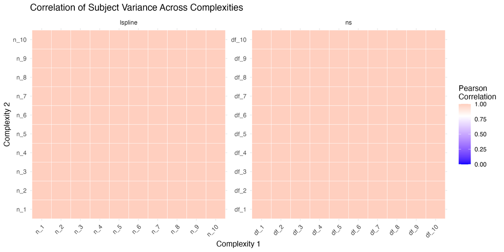

**Subject Variance Correlation:** Pearson correlations between Subject variance estimates across different dfs are near 1.0, indicating high stability.

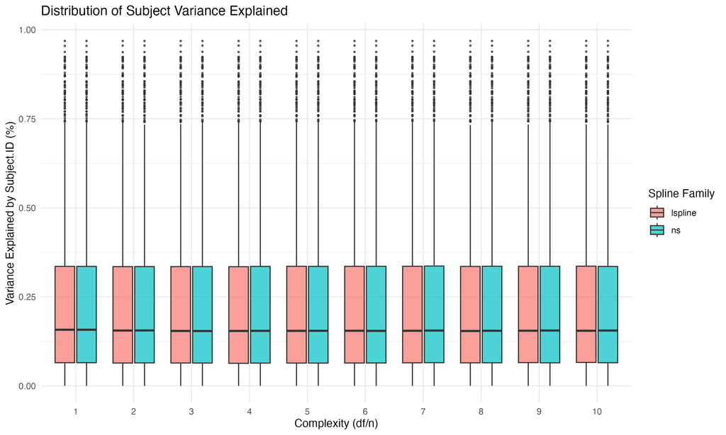

**Subject Variance Distribution:** The full distribution of Subject variance across the 1000 HVGs shows that individuality is a dominant and consistent signal regardless of the age model chosen.

### Inference Power

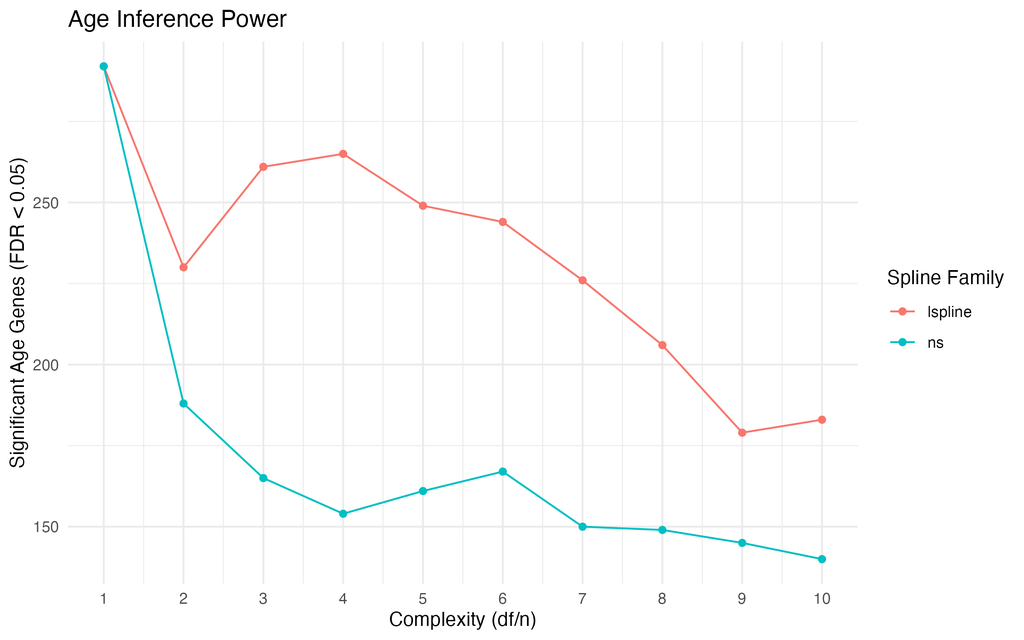

## Analysis 2: Advanced Variance Partitioning & Binned Age

This phase addressed the scale of Subject vs. Age effects using categorical and empirical approaches.

### “Realized Predictions” vs. Standard VP

We compared the **Standard** (population-level $\sigma^2$) approach to the **Realized Predictions** (empirical BLUP variance) method.

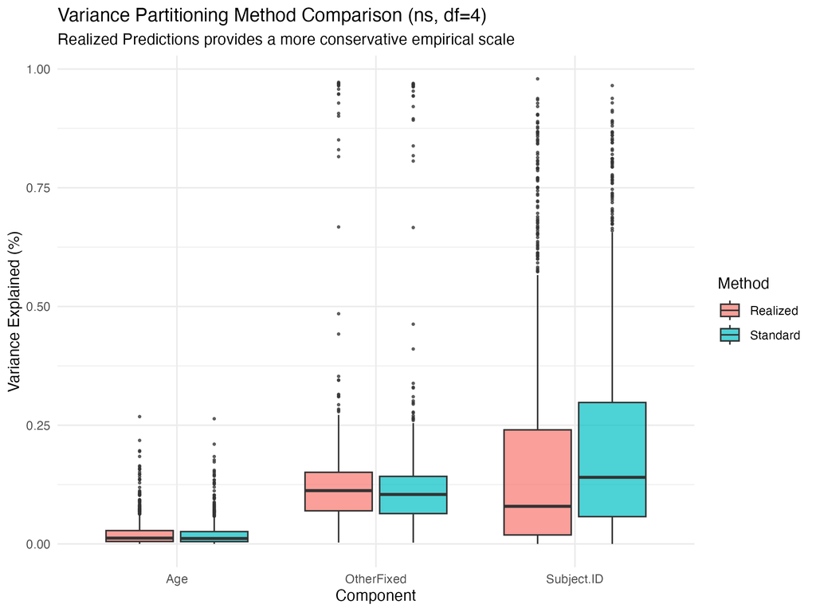

**VP Method Comparison:** The Realized approach provides a more conservative and biologically grounded estimate of Subject variance, accounting for the empirical distribution of individual intercepts.

### Binned Age and Model Architecture

We tested treating Age as a granular categorical random effect (`Age_Binned`, ~115 groups) and compared different architectures using AIC.

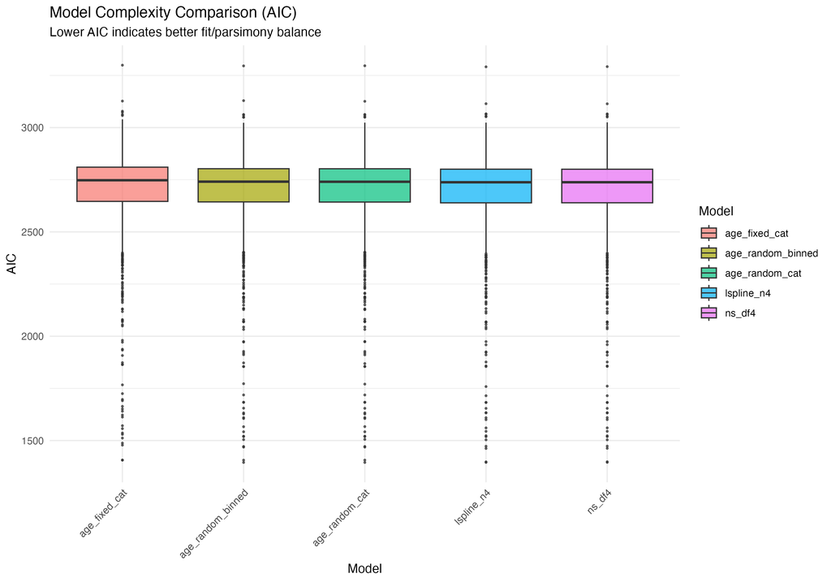

**Model AIC Comparison:** Spline-based models and categorical models show comparable AIC distributions, though splines offer smoother biological realism.

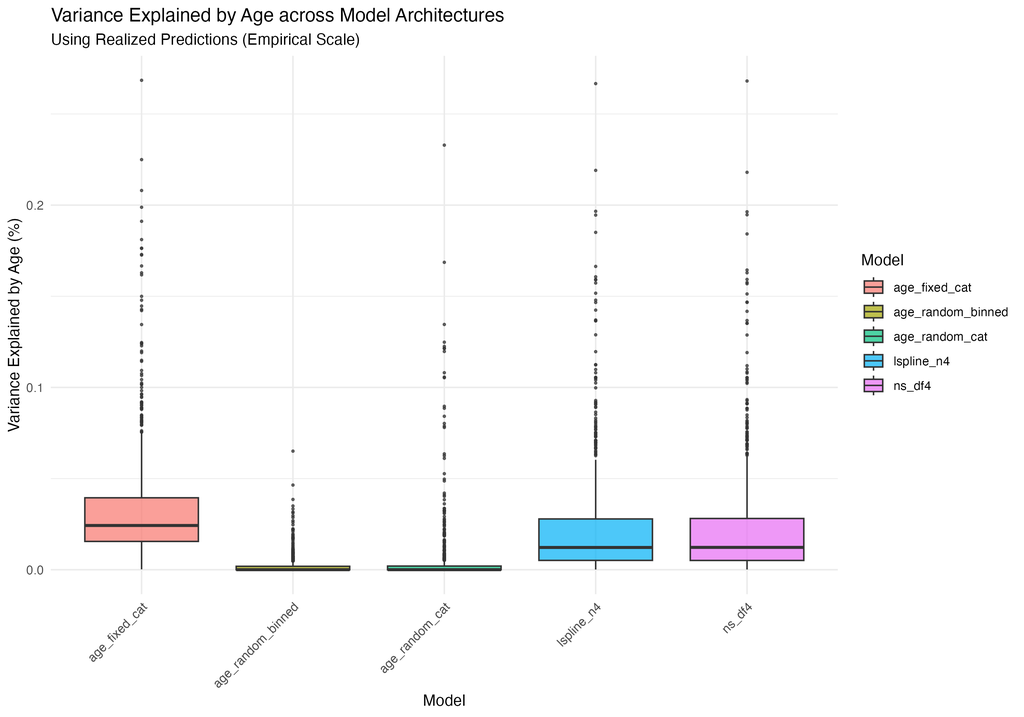

**Age Variance by Model:** The variance captured by Age remains relatively low (< 10% median) across all architectures, including highly flexible binned models.

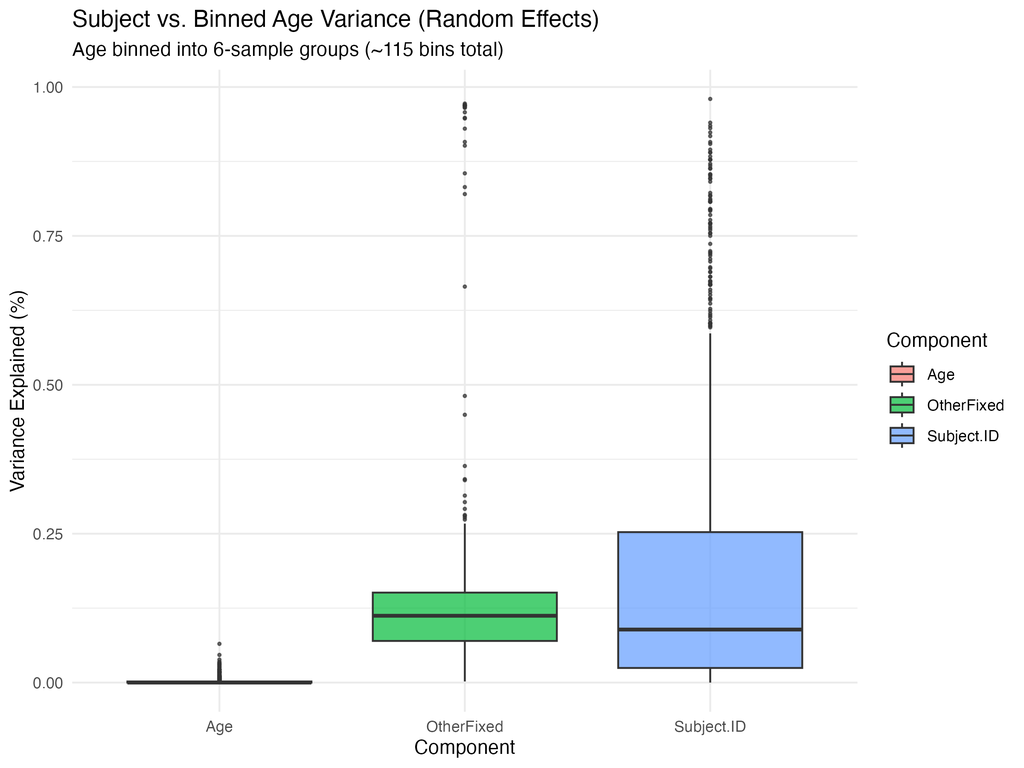

## Global Context

### Global Variance Partitioning

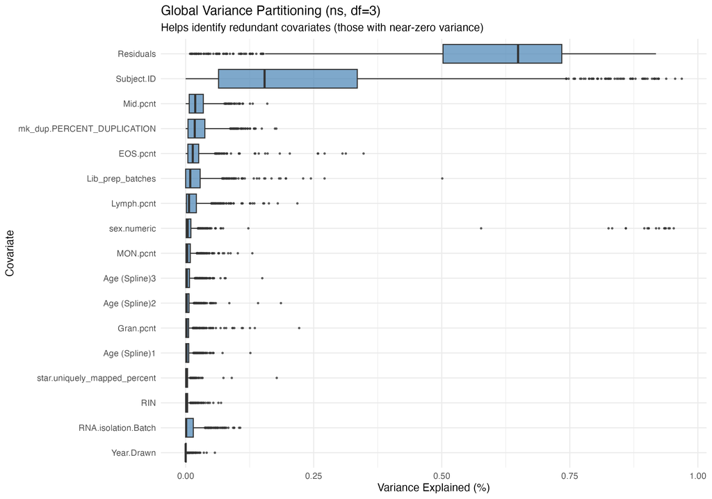

## Technical Implementation Notes

### Optimization Strategy

- **Optimizer:** All models were fit using the `bobyqa` optimizer via `lmerControl`, which provided superior convergence for complex spline terms compared to default solvers.
- **Scaling:** All continuous variables, including **Age.months**, were scaled and centered. This ensures that variance components are comparable and prevents numerical instability in the spline basis matrices.
- **Data Integrity:** A sample mismatch bug was identified and resolved by re-syncing the expression matrix rows to the metadata order after age-based sorting.

### Final Recommendation

The optimal model for capturing both smooth developmental trends and robust individual differences is: `~ (1|Subject.ID) + ns(Age.months, df=4) + (1|Batch) + [Cell Percentages] + [Technical Factors]`